# Not within spitting distance: salivary immunoassays of estradiol have subpar validity for cycle phase

Ruben Arslan

What properties do different measures of estradiol and progesterone have?

Below, you’ll find a complete tabular summary of the methods and results for each of the datasets (columns).

- Here, you’ll find the code generating the figures and tables in the manuscript.
- Here, you’ll find the code generating the imputations.
  - **Edit (2026-04-14):** I’ve since revised the imputation code to use multivariate imputations. Changes are minor, but you should still use the new MV imputations in the future.

## Tabular summary of analyses

```r
library(tidyverse)
library(gt)
library(brms)
source("0_summary_functions.R")
summary_table <- function(Hormone) {
  summaries <- list.files("summaries", full.names = T)
  summaries <- summaries[!str_detect(summaries, "(Ovulatory|OCMATE HC|BioCycle_Estradiol|Estradiol LCMS|\\.02\\.)")]
  summaries <- summaries[str_detect(summaries, pattern = Hormone)]
  summary_names <- str_match(summaries, "table_(.+?)\\.rds")[,2]
  message(paste(summary_names, "\n"))
  sus <- list()
  su_dfs <- list()
  for(s in seq_along(summaries)) {
    su <- rio::import(summaries[s])
    su_df <- su
    su_df$Sample <- summary_names[s]
    su_df$imputed_fc_vs_measured_graph <-
    su_df$imputed_bc_vs_measured_graph <-
    su_df$imputed_lh_vs_measured_graph <-
    su_df$bc_day_model <-
    su_df$fc_day_model <-
    su_df$lh_day_model <-
    su_df$distribution <- NULL
    su_df$rr_unrounded <- NULL
    su_df$rr_within_unrounded <- NULL
    su_df$imputed_fc_vs_measured_graph <-
    su_df$imputed_bc_vs_measured_graph <-
    su_df$imputed_lh_vs_measured_graph <-
    su_df$Distribution <-
    su_df$plot_bc <-
    su_df$plot_fc <-
    su_df$plot_lh <- summary_names[s]
    sus[[summary_names[s]]] <- su
    su_dfs[[summary_names[s]]] <- su_df %>% as_tibble() %>% mutate_if(is.numeric, ~ sprintf("%.2f", .))
  }

  comp_wide <- as_tibble(bind_rows(su_dfs, .id = "Sample")) %>%
    mutate_at(vars(n_women, n_cycles, n_days, missing, censored, outliers, usable_n, usable_n_women),
              ~ str_sub(., 1, -4))


  comp_wide <- comp_wide %>%
    mutate_at(vars(missing, censored, outliers), ~ sprintf("%.0f (%.0f%%)", as.numeric(.), 100*as.numeric(.)/as.numeric(n_days)))

  comp_wide <- comp_wide %>%
    mutate(Measure = paste0("LOD=", `Limit of detection`, ", LOQ=", LOQ, ", Intraassay CV=",`Intraassay CV`, ", Interassay CV=", `Interassay CV`)) %>%
    select(-`Limit of detection`, -`Intraassay CV`,
           -`Interassay CV`, -LOQ)

  Hormone_label <- names(sort(table(comp_wide$Hormone),decreasing = T))[1]

  comp_wide <- comp_wide %>%
    select(Sample, Dataset, Hormone, Citation, Method,
           Measure, Procedure, Scheduling, LH_test,
           Age = age,
           `In Relationship` = in_relationship,
           `Cycle length` = cycle_length,
           Women = n_women,
           Cycles = n_cycles,
           Days = n_days,
           `% women no LH surge` = no_lh_surge_woman,
           `% cycles no LH surge` = no_lh_surge_cycle,
           `Usable n women` = usable_n_women,
           `Usable n days` = usable_n,
           Distribution,
           logmean, logsd, missing, outliers, censored,
           mean, sd, median, mad, range,
           var_id_loo, var_cycle_loo,
           var_id, var_cycle, var_resid,
           r_fc_stirn, r_log_fc_stirn, r_diff_fc_stirn, r_log_diff_fc_stirn, r_loo_fc, r_fc_imputed,
           r_diff_fc_imputed, sd_fc_imputed, r_diff_fc_imputed_rr, r_within_fc_imputed, r_within_fc_imputed_rr,
           plot_fc,
           r_bc_stirn, r_log_bc_stirn, r_diff_bc_stirn, r_log_diff_bc_stirn, r_loo_bc, r_bc_imputed,
           r_diff_bc_imputed, sd_bc_imputed, r_diff_bc_imputed_rr, r_within_bc_imputed, r_within_bc_imputed_rr,
           plot_bc,
          r_prob_lh, r_log_prob_lh, r_diff_prob_lh, r_log_diff_prob_lh, r_loo_lh, r_lh_imputed,
           r_diff_lh_imputed, sd_lh_imputed, r_diff_lh_imputed_rr, r_within_lh_imputed, r_within_lh_imputed_rr,
           plot_lh,
           everything(), -matches("rmse_[^i]"), -contains("_vs_measured"))

  study_names <- c("BioCycle", "Roney 2013", "OCMATE Non-HC", "Marcinkowska 2020", "GOL2", "GOCD2", "Blake 2017", "Grebe et al. 2016")
  short_names <- c("BioCycle", "Roney '13", "OCMATE", "Marcinkowska '20", "Stern '21", "Jünger '18",  "Blake '17", "Grebe '16")
  names(short_names) <- study_names
  comp_wide$Dataset <- factor(as.character(short_names[comp_wide$Dataset]), levels = short_names)

  if(n_distinct(comp_wide$Sample) == n_distinct(comp_wide$Dataset)) {
    comp_wide$Sample <- comp_wide$Dataset
  }

  comp <- comp_wide %>%
    pivot_longer(-Sample)

  # comp$Sample <- str_trim(str_replace(str_replace(str_replace(
  #   comp$Sample, Hormone, ""), "Free", ""), "_", " "))

  comp <- comp %>% arrange(Sample)

  comp <- comp %>%
    pivot_wider(id_cols = name, names_from = Sample, values_from = value) %>%
    rename(rowname = name)

  comp <- comp %>%
    mutate(rowgroup = case_when(
      rowname %in% c("Hormone", "Dataset","Citation", "Scheduling") ~ "Study",
      rowname %in% c("Method", "Measure", "Procedure", "LH_test") ~ "Measure",
      rowname %in% c("Women", "Cycles", "Days", "Usable n women", "Usable n days", "Age", "In Relationship", "Cycle length", "% women no LH surge", "% cycles no LH surge") ~ "Sample",
      rowname %in% c("Distribution",
                     "logmean", "logsd", "missing", "censored", "outliers",
                     "mean", "sd", "median", "mad", "range") ~ "Descriptive statistics",
      rowname %in%  c("var_id_loo", "var_cycle_loo", "var_id", "var_cycle", "var_resid") ~ "Interindividual differences",
    rowname %in%  c("r_fc", "r_loo_fc", "plot_fc", "imputed_fc_vs_measured_graph",
           "r_fc_stirn", "r_log_fc_stirn", "r_diff_fc_stirn", "r_log_diff_fc_stirn", "rmse_fc", "r_fc_imputed", "r_diff_fc_imputed", "sd_fc_imputed", "r_diff_fc_imputed_rr", "r_within_fc_imputed", "r_within_fc_imputed_rr",  "rmse_fc_imputed") ~ "Validity (Forward counting)",
    rowname %in%  c("r_bc", "r_loo_bc", "plot_bc", "imputed_bc_vs_measured_graph",
           "r_bc_stirn", "r_log_bc_stirn", "r_diff_bc_stirn", "r_log_diff_bc_stirn", "rmse_bc", "r_bc_imputed", "r_diff_bc_imputed", "sd_bc_imputed", "r_diff_bc_imputed_rr", "r_within_bc_imputed", "r_within_bc_imputed_rr", "rmse_bc_imputed") ~ "Validity (Backward counting)",
    rowname %in%  c("r_lh", "r_loo_lh", "plot_lh", "imputed_lh_vs_measured_graph",
           "r_prob_lh", "r_log_prob_lh", "r_diff_prob_lh", "r_log_diff_prob_lh", "rmse_lh", "r_lh_imputed", "r_diff_lh_imputed", "sd_lh_imputed", "r_diff_lh_imputed_rr", "r_within_lh_imputed", "r_within_lh_imputed_rr",  "rmse_lh_imputed") ~ "Validity (LH)"
    ))
```

```r
  comp %>%
  gt(groupname_col = "rowgroup") %>%
  tab_header(
    title = paste0(Hormone_label, " measures"),
    subtitle = "Comparing salivary and serum measures on a variety of performance criteria"
  ) %>%
  text_transform(
    locations = cells_body(everything(), rowname == "Citation"),
      fn = function(x) {
            long <- x
            short <- str_match(str_trim(x), "^(.+?\\))")[,2]
            str_c("<small><details><summary>", short,"</summary>", long, "</details></small>")
        }
  ) %>%
  text_transform(
    locations = cells_body(everything(), rowname %in% c("Procedure", "Scheduling", "LH_test")),
      fn = function(x) {
          long <- x
          short <- str_match(x, "^(.+?)'")[,2]
          long <- str_match(x, "'(.+)'")[,2]
          short[is.na(short)] <- ""
          long[is.na(long)] <- x[is.na(long)]
          details <- str_c("<small>", short, "<details><summary>More</summary>", long, "</details></small>")
          details[is.na(x) | x == ""] <- ""
          details
        }
  ) %>%
  text_transform(
    locations = cells_body(everything(), rowname == "Distribution"),
      fn = function(x) {
        plots <- character(length(x))
        for(i in seq_along(x)) {
          message(x[i])
          if(!is.null(sus[[x[i]]]$distribution)) {
            if(Hormone_label == "Estradiol") {
              breaks <- c(0.2, 1, 2, 10, 15, 20, 30)
              limits <- c(0.2, 32)
            } else {
              breaks <- c(0.2, 1, 5, 10, 50, 100, 200, 500, 1000, 2000, 5000, 10000, 20000, 30000)
              limits <- c(0.2, 30000)
            }
            plots[i] <- { sus[[x[i]]]$distribution +
            scale_x_continuous(Hormone_label, breaks = breaks, labels = breaks,
                               limits = limits, trans = "log") +
            scale_fill_manual(values = c("none" = "black", "left" = "gray"), guide = FALSE) +
            geom_vline(xintercept = as.numeric(sus[[x[i]]]$`Limit of detection`),
                       linetype = 'solid') +
            geom_vline(xintercept = as.numeric(sus[[x[i]]]$LOQ),
                       linetype = 'dashed') +
            theme_minimal(base_size = 8) } %>%
            ggplot_image(height = px(200), aspect_ratio = 0.7)
          }
        }
        plots
      }
    ) %>% text_transform(
    locations = cells_body(everything(), rowname == "plot_fc"),
      fn = function(x) {
        plots <- character(length(x))
        for(i in seq_along(x)) {
          message(x[i])
          if(!is.null(sus[[x[i]]]$fc_day_model)) {
          plots[i] <- cycle_phase_plot(sus[[x[i]]], "fc_day_model", size = 6) %>%
            ggplot_image(height = px(600), aspect_ratio = 0.33)
          } else {
            plots[i] <- "NA"
          }
        }
        plots
      }
    ) %>% text_transform(
    locations = cells_body(everything(), rowname == "plot_bc"),
      fn = function(x) {
        plots <- character(length(x))
        for(i in seq_along(x)) {
          message(x[i])
          if(!is.null(sus[[x[i]]]$bc_day_model)) {
          plots[i] <- cycle_phase_plot(sus[[x[i]]], "bc_day_model", size = 6) %>%
            ggplot_image(height = px(600), aspect_ratio = 0.33)
          } else {
            plots[i] <- "NA"
          }
        }
        plots
      }
    ) %>% text_transform(
    locations = cells_body(everything(), rowname == "plot_lh"),
      fn = function(x) {
        plots <- character(length(x))
        for(i in seq_along(x)) {
          message(x[i])
          if(!is.null(sus[[x[i]]]$lh_day_model)) {
          plots[i] <- cycle_phase_plot(sus[[x[i]]], "lh_day_model", size = 6) %>%
            ggplot_image(height = px(600), aspect_ratio = 0.33)
          } else {
            plots[i] <- "NA"
          }
        }
        plots
      }
    ) %>%
    tab_style(
    style = list(
      cell_text(weight = "bold",
                size = "large")
      ),
    locations = cells_row_groups()
  ) %>%
    cols_width(everything() ~ px(230)
  )
}

ratio_summary_table <- function() {
  summaries <- list.files("summaries", full.names = T)
  summaries <- summaries[str_detect(summaries, pattern = "ratio")]
  summaries <- summaries[!str_detect(summaries, "(Ovulatory|OCMATE HC|Dinh)")]
  summary_names <- str_match(summaries, "table_(.+?)\\.")[,2]
  sus <- list()
  su_dfs <- list()
  for(s in seq_along(summaries)) {
    su <- rio::import(summaries[s])
    su_df <- su
    su_df$m_bc_prob_rat <-
      su_df$m_fc_prob_rat <-
      su_df$m_lh_prob_rat <-
      su_df$m_bc_prob <-
      su_df$m_fc_prob <-
      su_df$m_lh_prob <-
      su_df$scatterplot <- NULL
    su_df$plot_scatter <- summary_names[s]
    sus[[summary_names[s]]] <- su
    su_dfs[[summary_names[s]]] <- su_df
  }

comp_wide <- as_tibble(bind_rows(su_dfs, .id = "Sample")) %>%
  mutate_if(is.numeric, ~ sprintf("%.2f", .)) %>%
  mutate_at(vars(n_women, n_cycles, n_days, usable_n), ~ str_sub(., 1, -4)) %>%
  select(Dataset, Method,
         Women = n_women,
         Cycles = n_cycles,
         Days = n_days,
         `Usable n` = usable_n,
         plot_scatter,
         r_ep, r_log_ep, r_e_ratio, r_log_e_ratio, r_p_ratio, r_log_p_ratio, r_bc_ratio, r_bc_log_ratio, r_erat_bc, r_loo_bc, r_fc_ratio, r_fc_log_ratio, r_erat_fc, r_loo_fc, r_lh_ratio, r_lh_log_ratio, r_erat_lh, r_loo_lh,
         everything())


  study_names <- c("BioCycle", "Roney 2013", "OCMATE Non-HC", "Marcinkowska 2020", "GOL2", "GOCD2", "Blake 2017", "Grebe et al. 2016")
  short_names <- c("BioCycle", "Roney '13", "OCMATE", "Marcinkowska '20", "Stern '21", "Jünger '18", "Blake '17", "Grebe '16")
  names(short_names) <- study_names
  comp_wide$Dataset <- factor(as.character(short_names[comp_wide$Dataset]), levels = short_names)

  if(n_distinct(comp_wide$Sample) == n_distinct(comp_wide$Dataset)) {
    comp_wide$Sample <- comp_wide$Dataset
  }

comp <- comp_wide %>%
  pivot_longer(-Sample) %>%
  pivot_wider(id_cols = name, names_from = Sample, values_from = value) %>%
  rename(rowname = name)

colnames(comp) <- str_trim(str_replace(
  colnames(comp), "_", " "))
```

```r
Hormone_label <- names(sort(table(comp_wide$Hormone),decreasing = T))[1]

comp <- comp %>%
  mutate(rowgroup = case_when(
    rowname %in% c("Dataset", "Method", "Hormone") ~ "Measure",
    rowname %in% c("Women", "Cycles", "Days", "Usable n") ~ "Sample size",
  TRUE ~ "Relationship"
  ))

comp %>%
gt(groupname_col = "rowgroup") %>%
  tab_header(
    title = paste0("Estradiol and progesterone measures"),
    subtitle = "Comparing salivary and serum measures on a variety of performance criteria"
  ) %>%
  text_transform(
    locations = cells_body(everything(), 7),
      fn = function(x) {
        plots <- character(length(x))
        for(i in seq_along(x)) {
          message(x[i])
          if(!is.null(sus[[x[i]]]$scatterplot)) {
            plots[i] <- { sus[[x[i]]]$scatterplot +
            theme_minimal() } %>%
            ggplot_image(height = px(200))
          }
        }
        plots
      }
    )
}
```

### Estradiol (E2)

```r
summary_table("Estradiol")
```

Estradiol measures

Comparing salivary and serum measures on a variety of performance criteria

BioCycle

Roney '13

OCMATE

Marcinkowska '20

Stern '21

Jünger '18

Blake '17

Grebe '16

Study

Dataset

BioCycle

Roney '13

OCMATE

Marcinkowska '20

Stern '21

Jünger '18

Blake '17

Grebe '16

Hormone

Free Estradiol

Estradiol

Estradiol

Estradiol

Estradiol

Estradiol

Estradiol

Estradiol

Citation

**Wactawski-Wende, J., Schisterman, E. F., Hovey, K. M., Howards, P. P., Browne, R. W., Hediger, M., Liu, A., Trevisan, M., & BioCycle Study Group. (2009)**

Wactawski-Wende, J., Schisterman, E. F., Hovey, K. M., Howards, P. P., Browne, R. W., Hediger, M., Liu, A., Trevisan, M., & BioCycle Study Group. (2009). BioCycle study: design of the longitudinal study of the oxidative stress and hormone variation during the menstrual cycle. Paediatric and Perinatal Epidemiology, 23(2), 171–184. https://doi.org/10.1111/j.1365-3016.2008.00985.x Howards, P. P., Schisterman, E. F., Wactawski-Wende, J., Reschke, J. E., Frazer, A. A., & Hovey, K. M. (2009). Timing clinic visits to phases of the menstrual cycle by using a fertility monitor: the BioCycle Study. American Journal of Epidemiology, 169(1), 105–112. https://doi.org/10.1093/aje/kwn287 Prasad, A., Mumford, S. L., Buck Louis, G. M., Ahrens, K. A., Sjaarda, L. A., Schliep, K. C., Perkins, N. J., Kissell, K. A., Wactawski-Wende, J., & Schisterman, E. F. (2014). Sexual activity, endogenous reproductive hormones and ovulation in premenopausal women. Hormones and Behavior, 66(2), 330–338. https://doi.org/10.1016/j.yhbeh.2014.06.012

**Roney, J. R., & Simmons, Z. L. (2013)**

Roney, J. R., & Simmons, Z. L. (2013). Hormonal predictors of sexual motivation in natural menstrual cycles. Hormones and Behavior, 63(4), 636–645. https://doi.org/10.1016/j.yhbeh.2013.02.013

**Jones, B. C., Hahn, A. C., Fisher, C. I., Wang, H., Kandrik, M., Han, C., Fasolt, V., Morrison, D., Lee, A. J., Holzleitner, I. J., O’Shea, K. J., Roberts, S. C., Little, A. C., & DeBruine, L. M. (2018)**

Jones, B. C., Hahn, A. C., Fisher, C. I., Wang, H., Kandrik, M., Han, C., Fasolt, V., Morrison, D., Lee, A. J., Holzleitner, I. J., O’Shea, K. J., Roberts, S. C., Little, A. C., & DeBruine, L. M. (2018). No Compelling Evidence that Preferences for Facial Masculinity Track Changes in Women’s Hormonal Status. Psychological Science, 29(6), 996–1005. https://doi.org/10.1177/0956797618760197

**Marcinkowska, U. M. (2020)**

Marcinkowska, U. M. (2020). Importance of Daily Sex Hormone Measurements Within the Menstrual Cycle for Fertility Estimates in Cyclical Shifts Studies. Evolutionary Psychology: An International Journal of Evolutionary Approaches to Psychology and Behavior, 18(1), 1474704919897913. https://doi.org/10.1177/1474704919897913 Marcinkowska, U. M., Ellison, P. T., Galbarczyk, A., Milkowska, K., Pawlowski, B., Thune, I., & Jasienska, G. (2016). Lack of support for relation between woman’s masculinity preference, estradiol level and mating context. Hormones and Behavior, 78, 1–7. https://doi.org/10.1016/j.yhbeh.2015.10.012 Marcinkowska, U. M., Galbarczyk, A., & Jasienska, G. (2018). La donna è mobile? Lack of cyclical shifts in facial symmetry, and facial and body masculinity preferences-A hormone based study. Psychoneuroendocrinology, 88, 47–53. https://doi.org/10.1016/j.psyneuen.2017.11.007 Marcinkowska, U. M., Kaminski, G., Little, A. C., & Jasienska, G. (2018). Average ovarian hormone levels, rather than daily values and their fluctuations, are related to facial preferences among women. Hormones and Behavior, 102, 114–119. https://doi.org/10.1016/j.yhbeh.2018.05.013

**Stern, J., Kordsmeyer, T. L., & Penke, L. (2021)**

Stern, J., Kordsmeyer, T. L., & Penke, L. (2021). A longitudinal evaluation of ovulatory cycle shifts in women’s mate attraction and preferences. Hormones and Behavior, 128, 104916. https://doi.org/10.1016/j.yhbeh.2020.104916

**Jünger, J., Kordsmeyer, T. L., Gerlach, T. M., & Penke, L. (2018)**

Jünger, J., Kordsmeyer, T. L., Gerlach, T. M., & Penke, L. (2018). Fertile women evaluate male bodies as more attractive, regardless of masculinity. Evolution and Human Behavior: Official Journal of the Human Behavior and Evolution Society, 39(4), 412–423. https://doi.org/10.1016/j.evolhumbehav.2018.03.007

**Blake, K. R., Bastian, B., O’Dean, S. M., & Denson, T. F. (2017)**

Blake, K. R., Bastian, B., O’Dean, S. M., & Denson, T. F. (2017). High estradiol and low progesterone are associated with high assertiveness in women. Psychoneuroendocrinology, 75, 91–99. http://www.sciencedirect.com/science/article/pii/S0306453016302190

**Grebe, N. M., Emery Thompson, M., & Gangestad, S. W. (2016)**

Grebe, N. M., Emery Thompson, M., & Gangestad, S. W. (2016). Hormonal predictors of women’s extra-pair vs. in-pair sexual attraction in natural cycles: Implications for extended sexuality. Hormones and Behavior, 78, 211–219. https://doi.org/10.1016/j.yhbeh.2015.11.008

Scheduling

Distributed across cycle

**More**

, regularly menstruating premenopausal women for two menstrual cycles. Participants visited the clinic up to 8 times per cycle, at which time blood and urine were collected. The visits occurred at key hormonally defined phases of the menstrual cycle, with the help of an algorithm based on cycle length and data from a fertility monitor. The study included 16 cycle visits (eight per cycle) over two cycles. The timing of these visits was scheduled to correspond with specific times of the menstrual cycle where the most hormonal variation would be expected, approximately days 2, 7, 12, 13, 14, 18, 22 and 27 of a 28-day cycle, adjusted for cycle length (Table 4). Cycle visits were routinely scheduled between 7:00 AM and 8:30 AM to allow for collection of fasting samples and to reduce diurnal variation.

Every day for up to two cycles.

**More**

Here we collected daily saliva samples across 1–2 menstrual cycles from a sample of naturally cycling young women, as well as daily diary reports of both sexual behavior and self-reported sexual desire.

Irrespective of cycle.

**More**

Participants completed up to three blocks of test sessions (mean time between Block 1 and Block 2 = 230 days; mean time between Block 2 and Block 3 = 487 days). Each of the three blocks of test sessions consisted of five weekly test sessions. Table 1 shows how many women completed one, two, three, four, or five test sessions in Blocks 1 through 3.

Whole cycle

**More**

Participants were asked to collect saliva samples each morning starting from the first day of menstrual bleeding, until the end of the menstrual cycle (i.e., the day before the onset of the next menstrual bleeding). Due to financial restrictions on average 15 hormonal measurements were done per participant. For E centred around ovulation, for P last 15 days of the cycle.

peri-ovulatory (2x), mid-luteal und premenstrual

**More**

Sessions two to five were computer-based testing sessions and took place across different phases of the ovulatory cycle, scheduled based on backward counting and the observed LH test surge. Suitable testing days were computed with the help of an Excel sheet created for that purpose (see open material). All participants completed two sessions in their expected fertile phase (mid to late follicular phase, approx. 5–6 days before ovulation) and two sessions in their expected luteal phase (one session in the mid luteal phase, one session in the premenstrual phase). Scheduling was validated via LH test results and via following up to the day of the next menstrual onset. Details can be found in the supple- mentary material. The starting session for each participant depended on their current cycle phase at the introductory session and their personal schedule. Of all participants who finished all sessions, 134 participants started with the first session in their fertile phase, and 123 started in the luteal phase.

Peri-ovulatory & Luteal

**More**

Sessions two to five, the computer-based testing sessions, took place across two ovulatory cycles per participant, once per cycle during the fertile and once during the luteal phase. To control for possible effects of diurnal changes in hormone levels (Bao et al., 2003; Veldhuis et al., 1988), all sessions took place in the second half of the day (mainly between 11.30 am and 6 pm).

Fertile and non-fertile phase.

**More**

The repeated design of the study required that all participants attended one fertile and one non-fertile laboratory session. Hence, all participants included here detected a LH surge and thus had ovulatory cycles. Forty-seven percent of non-fertile sessions occurred in the early follicular phase (mean cycle day = 4.02, SD = 2.54) and the remain- der occurred in the late luteal phase (mean cycle day=26.06, SD=3.45). Most participants completed both fertile and non- fertile sessions in the same menstrual cycle (63.5%), the remainder attended sessions occurring 1, 2, or 3 cycles apart. Once a positive LH surge was detected, 85.4% of participants attended their fertile session within one day, the remaining 14.6% attended this session within two days. Following a surge in LH, ovulation is expected to occur approximately 24–48 h later (Direito et al., 2013).2

Irrespective of cycle phase.

**More**

We do emphasize that, although we sought to representatively sample days and phases of the cycle, by chance the luteal phase appears to have been overrepresented in our sample.

Measure

Method

Serum CL-EIA (chemiluminescence enzyme immunoassay) + mass-action-algorithm

Salivary immunoassay (Salimetrics)

Salivary immunoassay (Salimetrics)

Salivary immunoassay (DRG)

Salivary immunoassay (IBL)

Salivary immunoassay (IBL)

Salivary immunoassay (IBL)

Salivary immunoassay (Salimetrics)

Measure

LOD=0.21, LOQ=NA, Intraassay CV=NA, Interassay CV=<10

LOD=0.10, LOQ=1.00, Intraassay CV=4.52, Interassay CV=8.15

LOD=0.10, LOQ=1.00, Intraassay CV=7.13, Interassay CV=7.45

LOD=0.40, LOQ=1.00, Intraassay CV=7.5%, Interassay CV=10.1%

LOD=2.10, LOQ=2.10, Intraassay CV=8.80, Interassay CV=11.80

LOD=0.30, LOQ=0.90, Intraassay CV=9.70, Interassay CV=11.30

LOD=2.10, LOQ=NA, Intraassay CV=<12, Interassay CV=<12

LOD=0.10, LOQ=1.00, Intraassay CV=6.58, Interassay CV=2.68

Procedure

**More**

Blood collection and handling protocols were designed to minimize variability (Wactawski- Wende et al., 2009). All samples were processed and frozen at −80°C within 90 minutes of phlebotomy and analytes were measured in participant-specific batches within a single run to limit analytical variability. Estradiol, LH, follicle-stimulating hormone (FSH), and progesterone concentrations were measured in serum samples using solid-phase competitive chemiluminescent enzymatic immunoassays (DPC Immulite 2000 analyzer, Siemens Medical Solutions Diagnostics, Deerfield, IL) at the Kaleida Health Center for Laboratory Medicine (Buffalo, NY).

**More**

Women were also instructed to collect a saliva sample each morn- ing. They were asked to do so at least 30 min after any eating or drinking, ideally upon first waking. Collection was via passive drool (a few minutes after rinsing with clean water) into pre-labeled poly- propylene vials. Women stored these vials in home freezers and then delivered them weekly to our research lab, at which time they were given a new batch of vials. Saliva samples were then stored at − 80 C until being shipped for assay. Saliva samples were shipped on dry ice to the Endocrine Core Laboratory at the California Regional Primate Research Center, Davis, CA. Samples were centrifuged at 3000 rpm for 20 min. to separate the aqueous component from other particles. Concentrations of progester- one were estimated in duplicate using commercial radioimmunoassay kits (Siemens Health Diagnostics, Inc., Los Angeles, CA). Estradiol concentrations were estimated in duplicate using the high sensitivity salivary 17β-estradiol enzyme immunoassay kit (Salimetrics LLC, State College, PA). The estradiol assay has a least detectable dose of 0.1 pg/ml; intra- and inter-assay CVs were 4.52% and 8.15%, respectively.

**More**

Participants provided a saliva sample via passive drool (Papacosta & Nassis, 2011) in each test session. Partici- pants were instructed to avoid consuming alcohol and coffee in the 12 hr prior to participation and avoid eating, smoking, drinking, chewing gum, or brushing their teeth in the 60 min prior to participation. Each woman’s test sessions took place at approximately the same time of day to minimize effects of diurnal changes in hormone levels (Bao et al., 2003; Veldhuis et al., 1988). Saliva samples were frozen immediately and stored at −32° C until being shipped on dry ice to the Salimet- rics Lab (Suffolk, United Kingdom) for analysis, where they were assayed using the Salivary 17β-Estradiol Enzyme Immunoassay Kit 1-3702 (M = 3.30 pg/mL, SD = 1.27 pg/mL, sensitivity = 0.1 pg/mL, intra-assay coefficient of variability, or CV = 7.13%, inter-assay CV = 7.45%).

**More**

Participants were asked to collect saliva samples each morning starting from the first day of menstrual bleeding, until the end of the menstrual cycle (i.e., the day before the onset of the next menstrual bleeding). Women were verbally instructed by the principal investigator concerning collecting and storing the saliva and were given a set of 2-ml centrifuge tubes with the minimum amount of required saliva marked on a tube together with written instructions. Saliva samples were collected in the morning, preferably before eating, drinking, or smoking, or not earlier than 30 min after eating, drinking, or smoking. Immediately after collec- tion, samples were frozen in the participant’s home freezer. After the end of the cycle, samples were transported in portable freezers to the laboratory where hormonal assays for measure- ments of 17-b-estradiol (E2) and 17-a-hydroxy-progesterone (P) were conducted. Hormonal measurements were conducted using commercially available hormonal assays of DRG Inter- national, Inc. ELISA plates SLV4188 (sensitivity: 0.4 pg/ml, standard range: 1–100 pg/ml) for E2 and SLV3140 for P (sen- sitivity: 2.5 pg/ml, standard range: 10–5,000 pg/ml). All sam- ples were assayed in duplicates. The quality of hormonal measurements was monitored for each plate separately by including samples of known concentrations with low and high E2 and P levels. Inter-assay variability was 10.1%, intra-assay variability was 7.5% for E2 and 14.1% and 4.9% for P, which is within acceptable values for steroid sex hormones assays (Schultheiss & Stanton, 2009).

**More**

For hormone assays, we collected four saliva samples from each participant (one per testing session). Contamination of saliva samples was minimized by asking participants to abstain from eating, drinking (except plain water), smoking, chewing gum, or brushing teeth for at least one hour before each session. The samples were stored at − 80 ◦C directly after collection until shipment on dry ice to the Kirschbaum Lab at Technical University of Dresden, Germany (one freeze-thaw cycle). The samples were reanalyzed for estradiol using the highly sensitive 17β-estradiol enzyme immunoassay kit (IBL International, Hamburg, Germany). Samples were analyzed in singlets, however, the lab reported that their procedure yields CVs < 11%.

**More**

Next, the saliva samples were collected via passive drool. For hormone assays, we collected four saliva samples from each participant (one per testing session). Contamination of saliva samples was minimized by asking participants to abstain from eating, drinking (except plain water), smoking, chewing gum or brushing teeth for at least one hour before each session. The samples were stored at -80°C directly after collection until shipment on dry ice to the Kirschbaum Lab at Technical University of Dresden, Germany, where estradiol, progesterone, testosterone and cortisol was assessed via liquid chromatography mass spectrometry (LCMS; Gao, Stalder, & Kirschbaum, 2015). Since the LCMS analysis of the estradiol levels did only detect 22% of all possible values, the samples were reanalyzed using the highly sensitive 17β-estradiol enzyme immunoassay kit (IBL International, Hamburg, Germany). These latter estradiol values were used in subsequent analyses.

**More**

Progesterone and estradiol samples were stored at −20◦C and analyzed by a professional reference laboratory in Dresden, Germany. After thawing, samples were centrifuged at 3000 rpm for five minutes, which resulted in a clear supernatant of low viscosity. Salivary progesterone and estradiol concentrations were measured using commercially available chemiluminescence-immuno-assays with high sensitivity (IBL International, Hamburg, Germany). Intra- and inter-assay coefficients of variations for both hormones were below 12%.

**More**

We asked participants to provide saliva samples (~5 mL) via passive drool, from which we assayed estradiol, progesterone, and testosterone twice during the study: once during an initial session, and once upon awakening the day of a follow-up session one week later. Saliva samples were pipetted from a cup to test tubes, then frozen at -20° C. Prior to assays, frozen samples were thawed, mixed by vortexing, then centrifuged for 15 minutes to break up and precipitate mucins. Salivary 17β estradiol, progesterone, and testosterone concentrations were determined using enzyme-linked immunosorbent assays (ELISA) designed for saliva by Salimetrics LLC (Carlsbad, CA).

LH_test

**More**

Participants were also provided with and trained to use the Clearblue Easy Fertility Monitor (Inverness Medical Innovations, Inc., Waltham, Massachusetts) (www. clearblueeasy.com). The fertility monitor was originally developed to assist women in becoming pregnant by helping them to identify their fertile window through measurement of both estrone- 3-glucuronide (E3G) and LH in urine as described in greater detail elsewhere (13). Briefly, the monitor is synchronized to a woman’s cycle and then is checked daily to see whether a test is requested. Between the sixth and the ninth days of a woman’s cycle (depending on her cycle length history), the monitor begins to request daily tests for 10 days. On test days, the woman briefly submerges a test stick in her first- morning urine and then inserts the test stick into the monitor. The test stick has a nitrocellulose strip with an anti-LH antibody zone and an E3G conjugate zone. The monitor optically reads the level of E3G and LH in the urine by the intensity of the lines in the corresponding zones (13). Each day, the monitor assigns the woman to low, high, or peak fertility on the basis of her E3G and LH levels. Thus, unlike home LH test sticks, the monitor provides informa- tion to help anticipate the LH surge.

**More**

All participants received LH kits. Each kit consisted of sterilized urine cups and 10 LH tests. Women were instructed to conduct the tests from the 10th until the 20th day of the cycle or until a positive result was obtained.

**More**

highly sensitive (10mIU) LH urine ovulation test strips from MedNet GmbH. Participants started LH-testing after menstruation (around reverse cycle day 21) and continued until a rise of LH (positive tests) was observed and a minimum of two days after the tests were negative again (as suggested by Roney, 2018b). Participants were provided with a minimum of ten LH tests each and provided daily pictures of the tests to the investigators for confir- mation. LH results were used to allow flexible scheduling in case LH test results differed from the scheduling based on counting (see supplementary material for details).

**More**

highly sensitive (10 mIU/ml) urine ovulation test strips from purbay®, which measure the luteinizing hormone (LH). These LH-tests had to be done at home at the estimated day of ovulation and the four days prior to that and results were self- reported by the participants.

**More**

To maximize the likelihood of detecting surges in LH, we fol- lowed the standardized LH testing procedure in Blake et al. (2016b). All participants used commercially available urinary LH tests (Blue Cross Bio-Medical Co. LTD, CE/FDA Registered) and tested until a positive surge was detected. Wave 1 participants tested until a positive result was reported (a maximum of 10days) and Wave 2 tested for 11 continuous days, even if a surge was reported ear- lier. We instructed participants to test between 1000 h and 2000 h and report the result to the research team via SMS or email. The repeated design of the study required that all participants attended one fertile and one non-fertile laboratory session. Hence, all participants included here detected a LH surge and thus had ovulatory cycles. Participants who did not record a surge in LH were not eligible for inclusion in the study (see Blake et al., 2016b for full details of the sampling procedure).

Sample

Age

27.3±8.21

NA

21.5±3.29

NA

23.1±3.28

23.2±3.45

22.7±4.87

NA

In Relationship

25%

NA

36%

NA

47%

48%

53%

NA

Cycle length

28.8±4.10

27.6±5.06

29.7±6.73

28.2±2.99

30.0±4.75

29.5±6.54

29.2±2.39

28.8±3.71

Women

259

43

384

102

257

157

60

33

Cycles

509

122

907

102

454

398

86

33

Days

4072

2367

2394

2233

1028

628

120

66

% women no LH surge

43/257 (17%)

NA

NA

25/100 (25%)

47/243 (19%)

9/125 (7%)

0/58 (0%)

NA

% cycles no LH surge

141/481 (29%)

NA

NA

25/100 (25%)

145/406 (36%)

57/243 (23%)

26/84 (31%)

NA

Usable n women

257

42

360

100

243

157

58

31

Usable n days

3682

1091

1664

1647

914

549

114

58

Descriptive statistics

Distribution

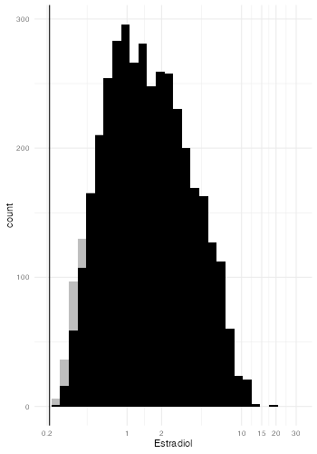

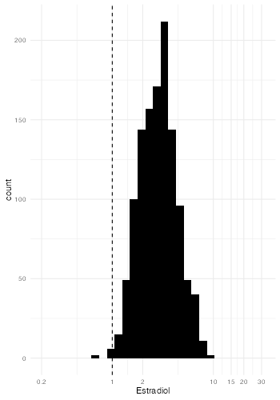

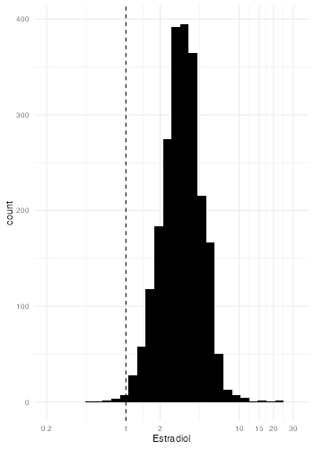

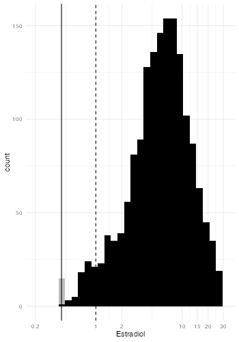

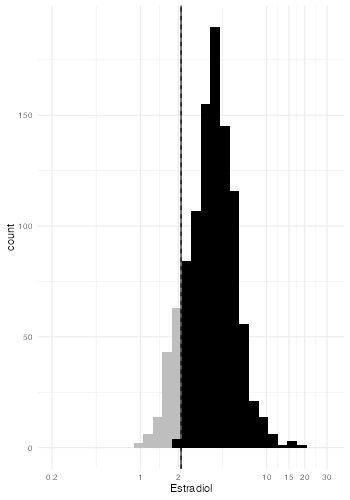

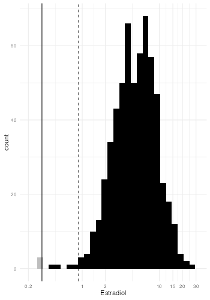

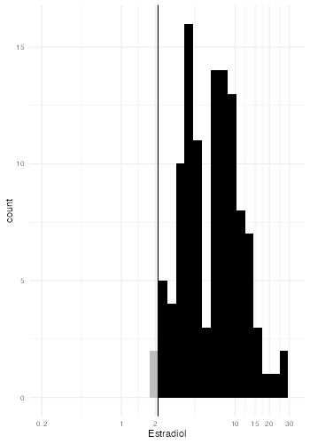

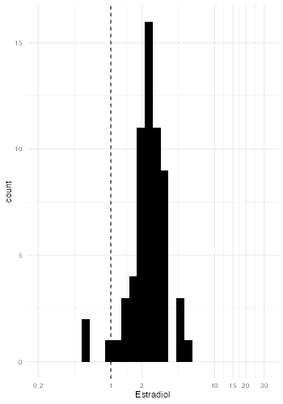

logmean

0.40

1.04

1.13

1.70

1.29

1.57

1.84

0.82

logsd

0.84

0.42

0.41

0.86

0.44

0.67

0.57

0.42

missing

171 (4%)

1169 (49%)

103 (4%)

553 (25%)

1 (0%)

32 (5%)

6 (5%)

4 (6%)

outliers

0 (0%)

0 (0%)

9 (0%)

0 (0%)

4 (0%)

0 (0%)

0 (0%)

0 (0%)

censored

89 (2%)

0 (0%)

0 (0%)

14 (1%)

124 (12%)

3 (0%)

2 (2%)

0 (0%)

mean

2.13

3.10

3.36

7.61

4.00

5.88

7.42

2.45

sd

1.95

1.34

1.55

6.40

1.89

3.93

4.74

0.92

median

1.42

2.89

3.11

5.96

3.71

5.00

6.88

2.25

mad

1.19

1.25

1.23

4.38

1.54

3.13

4.13

0.75

range

0.21, 18.28

0.67, 9.17

0.48, 24.22

0.40, 46.52

1.01, 19.05

0.30, 31.00

2.10, 28.81

0.53, 5.62

Interindividual differences

var_id_loo

0.06 [0.04;0.07]

0.23 [0.18;0.27]

0.47 [0.43;0.51]

0.52 [0.48;0.56]

0.16 [0.11;0.22]

0.14 [0.08;0.19]

-0.03 [-0.06;-0.01]

0.22 [-0.03;0.40]

var_cycle_loo

0.06 [0.04;0.07]

0.27 [0.23;0.32]

0.51 [0.47;0.54]

NA

0.16 [0.10;0.22]

0.14 [0.08;0.19]

-0.05 [-0.08;-0.03]

NA

var_id

0.27 [0.23;0.31] (10%)

0.19 [0.13;0.26] (20%)

0.30 [0.27;0.33] (50%)

0.66 [0.57;0.77] (55%)

0.27 [0.22;0.31] (34%)

0.35 [0.27;0.43] (27%)

0.09 [0.00;0.23] (3%)

0.31 [0.15;0.46] (48%)

var_cycle

0.03 [0.00;0.07] (0%)

0.16 [0.11;0.21] (13%)

0.14 [0.11;0.17] (12%)

NA

0.07 [0.00;0.17] (4%)

0.13 [0.01;0.28] (5%)

0.10 [0.00;0.27] (4%)

NA

var_resid

0.81 [0.79;0.83] (90%)

0.35 [0.33;0.37] (68%)

0.26 [0.25;0.27] (38%)

0.59 [0.56;0.61] (45%)

0.40 [0.37;0.42] (62%)

0.55 [0.51;0.60] (68%)

0.58 [0.50;0.67] (92%)

0.32 [0.24;0.42] (52%)

Validity (Forward counting)

r_fc_stirn

0.24 [ 0.21; 0.27]

0.03 [-0.03; 0.09]

-0.00 [-0.05; 0.05]

0.07 [ 0.02; 0.12]

0.00 [-0.06; 0.06]

-0.05 [-0.15; 0.05]

0.08 [-0.11; 0.26]

-0.04 [-0.29; 0.22]

r_log_fc_stirn

0.25 [ 0.22; 0.28]

0.02 [-0.04; 0.08]

-0.00 [-0.05; 0.05]

0.05 [ 0.01; 0.10]

0.00 [-0.06; 0.07]

-0.00 [-0.11; 0.10]

0.10 [-0.09; 0.27]

0.06 [-0.20; 0.31]

r_diff_fc_stirn

0.25 [ 0.22; 0.28]

0.05 [-0.01; 0.11]

-0.01 [-0.06; 0.04]

0.05 [ 0.00; 0.10]

0.02 [-0.05; 0.08]

-0.02 [-0.12; 0.08]

0.13 [-0.06; 0.30]

-0.13 [-0.37; 0.14]

r_log_diff_fc_stirn

0.26 [ 0.23; 0.29]

0.04 [-0.02; 0.10]

-0.02 [-0.07; 0.03]

0.03 [-0.02; 0.08]

0.02 [-0.04; 0.09]

0.05 [-0.05; 0.15]

0.14 [-0.05; 0.31]

-0.12 [-0.37; 0.14]

r_loo_fc

0.57 [0.55;0.59]

0.14 [NaN;0.21]

NaN [NaN;NaN]

NaN [NaN;NaN]

NaN [NaN;0.02]

NaN [NaN;0.07]

NaN [NaN;0.09]

NaN [NaN;NaN]

r_fc_imputed

0.57 [ 0.55; 0.59]

0.21 [ 0.15; 0.26]

0.07 [ 0.02; 0.12]

0.10 [ 0.05; 0.15]

0.04 [-0.02; 0.11]

0.10 [-0.01; 0.20]

0.17 [-0.01; 0.34]

0.12 [-0.14; 0.37]

r_diff_fc_imputed

0.62 [ 0.60; 0.64]

0.21 [ 0.15; 0.27]

0.15 [ 0.10; 0.20]

0.17 [ 0.13; 0.22]

0.05 [-0.01; 0.12]

0.11 [ 0.01; 0.21]

0.14 [-0.05; 0.32]

-0.05 [-0.31; 0.21]

sd_fc_imputed

0.50 (93%)

0.48 (87%)

0.52 (101%)

0.40 (60%)

0.37 (51%)

0.31 (36%)

0.46 (78%)

0.50 (93%)

r_diff_fc_imputed_rr

0.63 [ 0.61; 0.65]

0.23 [ 0.16; 0.29]

0.15 [ 0.10; 0.19]

0.22 [ 0.16; 0.28]

0.07 [-0.02; 0.16]

0.18 [ 0.01; 0.33]

0.16 [-0.05; 0.35]

-0.05 [-0.32; 0.22]

r_within_fc_imputed

0.62 [ 0.60; 0.64]

0.22 [ 0.16; 0.27]

0.16 [ 0.10; 0.21]

0.18 [ 0.13; 0.23]

0.06 [-0.02; 0.13]

0.13 [ 0.01; 0.25]

0.17 [-0.09; 0.41]

-0.06 [-0.43; 0.32]

r_within_fc_imputed_rr

0.62 [ 0.60; 0.64]

0.23 [ 0.17; 0.29]

0.15 [ 0.09; 0.20]

0.23 [ 0.17; 0.29]

0.07 [-0.03; 0.17]

0.20 [ 0.01; 0.38]

0.17 [-0.09; 0.40]

-0.06 [-0.38; 0.28]

plot_fc

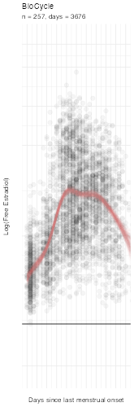

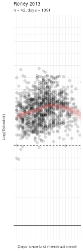

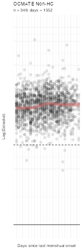

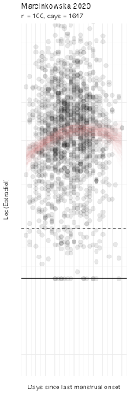

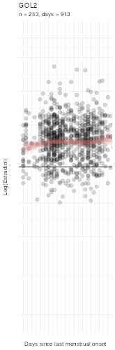

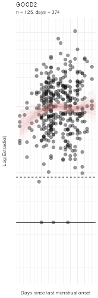

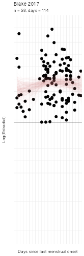

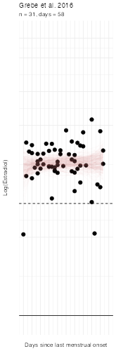

r_fc

0.58 [0.57;0.60]

0.22 [0.16;0.26]

0.12 [0.09;0.16]

0.12 [0.09;0.15]

0.09 [0.02;0.15]

0.14 [0.04;0.23]

0.19 [0.03;0.34]

0.18 [0.03;0.34]

Validity (Backward counting)

r_bc_stirn

0.34 [ 0.31; 0.37]

-0.06 [-0.12; 0.01]

-0.01 [-0.08; 0.06]

0.08 [ 0.03; 0.13]

0.01 [-0.06; 0.07]

0.03 [-0.06; 0.11]

0.04 [-0.15; 0.23]

NA

r_log_bc_stirn

0.36 [ 0.33; 0.39]

-0.06 [-0.12; 0.00]

-0.00 [-0.08; 0.07]

0.08 [ 0.03; 0.13]

0.01 [-0.05; 0.08]

0.04 [-0.05; 0.12]

0.07 [-0.12; 0.25]

NA

r_diff_bc_stirn

0.36 [ 0.33; 0.39]

-0.04 [-0.10; 0.02]

-0.03 [-0.10; 0.04]

0.08 [ 0.04; 0.13]

-0.02 [-0.09; 0.04]

0.01 [-0.07; 0.09]

0.06 [-0.13; 0.25]

NA

r_log_diff_bc_stirn

0.37 [ 0.34; 0.40]

-0.05 [-0.11; 0.01]

-0.02 [-0.09; 0.05]

0.07 [ 0.03; 0.12]

-0.01 [-0.07; 0.06]

0.02 [-0.06; 0.10]

0.07 [-0.11; 0.26]

NA

r_loo_bc

0.68 [0.66;0.69]

0.13 [NaN;0.20]

NaN [NaN;NaN]

NaN [NaN;NaN]

NaN [NaN;NaN]

NaN [NaN;NaN]

NaN [NaN;NaN]

NA

r_bc_imputed

0.68 [ 0.66; 0.70]

0.15 [ 0.09; 0.21]

0.08 [ 0.01; 0.15]

0.15 [ 0.10; 0.19]

0.03 [-0.03; 0.10]

0.10 [ 0.01; 0.18]

0.12 [-0.07; 0.30]

NA

r_diff_bc_imputed

0.72 [ 0.71; 0.74]

0.17 [ 0.11; 0.23]

0.15 [ 0.09; 0.22]

0.21 [ 0.16; 0.25]

0.02 [-0.04; 0.09]

0.14 [ 0.05; 0.22]

0.11 [-0.08; 0.29]

NA

sd_bc_imputed

0.59 (86%)

0.50 (63%)

0.51 (64%)

0.48 (58%)

0.50 (63%)

0.40 (41%)

0.53 (71%)

NA

r_diff_bc_imputed_rr

0.75 [ 0.73; 0.76]

0.22 [ 0.14; 0.29]

0.19 [ 0.11; 0.27]

0.27 [ 0.21; 0.33]

0.03 [-0.05; 0.11]

0.21 [ 0.08; 0.33]

0.13 [-0.10; 0.34]

NA

r_within_bc_imputed

0.73 [ 0.72; 0.75]

0.18 [ 0.11; 0.23]

0.16 [ 0.08; 0.25]

0.22 [ 0.17; 0.26]

0.02 [-0.06; 0.10]

0.16 [ 0.06; 0.25]

0.13 [-0.15; 0.39]

NA

r_within_bc_imputed_rr

0.75 [ 0.73; 0.76]

0.22 [ 0.14; 0.29]

0.19 [ 0.09; 0.28]

0.29 [ 0.22; 0.34]

0.02 [-0.07; 0.12]

0.24 [ 0.09; 0.38]

0.14 [-0.15; 0.40]

NA

plot_bc

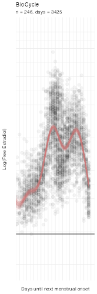

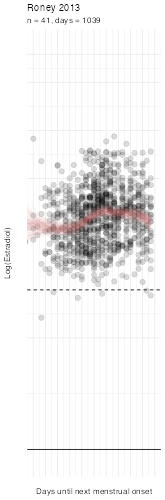

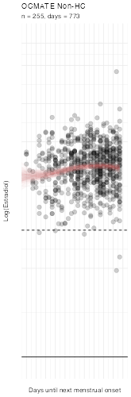

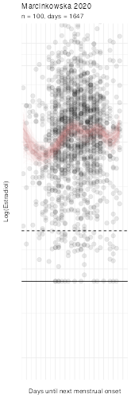

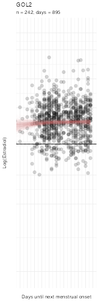

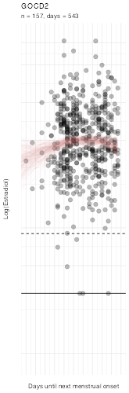

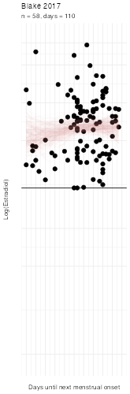

NA

r_bc

0.69 [0.67;0.70]

0.22 [0.17;0.26]

0.13 [0.08;0.17]

0.16 [0.13;0.19]

0.06 [0.01;0.11]

0.11 [0.03;0.18]

0.18 [0.03;0.33]

NA

Validity (LH)

r_prob_lh

0.57 [ 0.54; 0.59]

NA

NA

0.09 [ 0.03; 0.14]

0.05 [-0.03; 0.13]

0.03 [-0.06; 0.13]

0.06 [-0.16; 0.26]

NA

r_log_prob_lh

0.54 [ 0.51; 0.56]

NA

NA

0.10 [ 0.04; 0.16]

0.06 [-0.02; 0.14]

0.06 [-0.04; 0.15]

0.11 [-0.10; 0.31]

NA

r_diff_prob_lh

0.61 [ 0.58; 0.63]

NA

NA

0.12 [ 0.07; 0.18]

0.04 [-0.04; 0.11]

0.04 [-0.05; 0.14]

0.19 [-0.03; 0.38]

NA

r_log_diff_prob_lh

0.57 [ 0.55; 0.60]

NA

NA

0.14 [ 0.08; 0.19]

0.05 [-0.03; 0.13]

0.07 [-0.03; 0.16]

0.20 [-0.01; 0.39]

NA

r_loo_lh

0.72 [0.70;0.74]

NA

NA

NaN [NaN;NaN]

NaN [NaN;0.11]

NaN [NaN;NaN]

NaN [NaN;NaN]

NA

r_lh_imputed

0.72 [ 0.70; 0.74]

NA

NA

0.12 [ 0.07; 0.18]

0.10 [ 0.03; 0.18]

0.07 [-0.02; 0.17]

0.01 [-0.20; 0.22]

NA

r_diff_lh_imputed

0.76 [ 0.74; 0.78]

NA

NA

0.18 [ 0.13; 0.24]

0.10 [ 0.03; 0.18]

0.06 [-0.03; 0.16]

0.03 [-0.18; 0.24]

NA

sd_lh_imputed

0.60 (85%)

NA

NA

0.53 (66%)

0.51 (60%)

0.43 (43%)

0.42 (40%)

NA

r_diff_lh_imputed_rr

0.79 [ 0.77; 0.80]

NA

NA

0.22 [ 0.16; 0.29]

0.13 [ 0.03; 0.23]

0.10 [-0.05; 0.24]

0.05 [-0.28; 0.36]

NA

r_within_lh_imputed

0.77 [ 0.76; 0.79]

NA

NA

0.18 [ 0.13; 0.24]

0.13 [ 0.04; 0.22]

0.08 [-0.04; 0.20]

-0.00 [-0.36; 0.35]

NA

r_within_lh_imputed_rr

0.79 [ 0.77; 0.80]

NA

NA

0.22 [ 0.15; 0.29]

0.17 [ 0.05; 0.28]

0.12 [-0.05; 0.29]

-0.00 [-0.45; 0.45]

NA

plot_lh

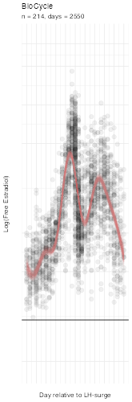

NA

NA

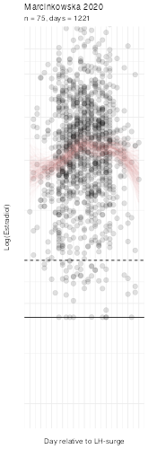

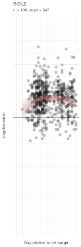

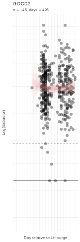

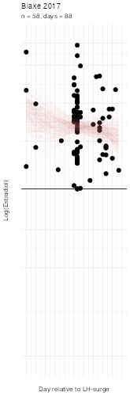

NA

r_lh

0.73 [0.71;0.74]

NA

NA

0.13 [0.09;0.17]

0.14 [0.05;0.21]

0.08 [0.01;0.16]

0.20 [0.04;0.36]

NA

### Progesterone (P4)

```r
summary_table("Progesterone")
```

Progesterone measures

Comparing salivary and serum measures on a variety of performance criteria

BioCycle

Roney '13

OCMATE

Marcinkowska '20

Stern '21

Jünger '18

Blake '17

Grebe '16

Study

Dataset

BioCycle

Roney '13

OCMATE

Marcinkowska '20

Stern '21

Jünger '18

Blake '17

Grebe '16

Hormone

Progesterone

Progesterone

Progesterone

Progesterone

Progesterone

Progesterone

Progesterone

Progesterone

Citation

**Wactawski-Wende, J., Schisterman, E. F., Hovey, K. M., Howards, P. P., Browne, R. W., Hediger, M., Liu, A., Trevisan, M., & BioCycle Study Group. (2009)**

Wactawski-Wende, J., Schisterman, E. F., Hovey, K. M., Howards, P. P., Browne, R. W., Hediger, M., Liu, A., Trevisan, M., & BioCycle Study Group. (2009). BioCycle study: design of the longitudinal study of the oxidative stress and hormone variation during the menstrual cycle. Paediatric and Perinatal Epidemiology, 23(2), 171–184. https://doi.org/10.1111/j.1365-3016.2008.00985.x Howards, P. P., Schisterman, E. F., Wactawski-Wende, J., Reschke, J. E., Frazer, A. A., & Hovey, K. M. (2009). Timing clinic visits to phases of the menstrual cycle by using a fertility monitor: the BioCycle Study. American Journal of Epidemiology, 169(1), 105–112. https://doi.org/10.1093/aje/kwn287 Prasad, A., Mumford, S. L., Buck Louis, G. M., Ahrens, K. A., Sjaarda, L. A., Schliep, K. C., Perkins, N. J., Kissell, K. A., Wactawski-Wende, J., & Schisterman, E. F. (2014). Sexual activity, endogenous reproductive hormones and ovulation in premenopausal women. Hormones and Behavior, 66(2), 330–338. https://doi.org/10.1016/j.yhbeh.2014.06.012

**Roney, J. R., & Simmons, Z. L. (2013)**

Roney, J. R., & Simmons, Z. L. (2013). Hormonal predictors of sexual motivation in natural menstrual cycles. Hormones and Behavior, 63(4), 636–645. https://doi.org/10.1016/j.yhbeh.2013.02.013

**Jones, B. C., Hahn, A. C., Fisher, C. I., Wang, H., Kandrik, M., Han, C., Fasolt, V., Morrison, D., Lee, A. J., Holzleitner, I. J., O’Shea, K. J., Roberts, S. C., Little, A. C., & DeBruine, L. M. (2018)**

Jones, B. C., Hahn, A. C., Fisher, C. I., Wang, H., Kandrik, M., Han, C., Fasolt, V., Morrison, D., Lee, A. J., Holzleitner, I. J., O’Shea, K. J., Roberts, S. C., Little, A. C., & DeBruine, L. M. (2018). No Compelling Evidence that Preferences for Facial Masculinity Track Changes in Women’s Hormonal Status. Psychological Science, 29(6), 996–1005. https://doi.org/10.1177/0956797618760197

**Marcinkowska, U. M. (2020)**

Marcinkowska, U. M. (2020). Importance of Daily Sex Hormone Measurements Within the Menstrual Cycle for Fertility Estimates in Cyclical Shifts Studies. Evolutionary Psychology: An International Journal of Evolutionary Approaches to Psychology and Behavior, 18(1), 1474704919897913. https://doi.org/10.1177/1474704919897913 Marcinkowska, U. M., Ellison, P. T., Galbarczyk, A., Milkowska, K., Pawlowski, B., Thune, I., & Jasienska, G. (2016). Lack of support for relation between woman’s masculinity preference, estradiol level and mating context. Hormones and Behavior, 78, 1–7. https://doi.org/10.1016/j.yhbeh.2015.10.012 Marcinkowska, U. M., Galbarczyk, A., & Jasienska, G. (2018). La donna è mobile? Lack of cyclical shifts in facial symmetry, and facial and body masculinity preferences-A hormone based study. Psychoneuroendocrinology, 88, 47–53. https://doi.org/10.1016/j.psyneuen.2017.11.007 Marcinkowska, U. M., Kaminski, G., Little, A. C., & Jasienska, G. (2018). Average ovarian hormone levels, rather than daily values and their fluctuations, are related to facial preferences among women. Hormones and Behavior, 102, 114–119. https://doi.org/10.1016/j.yhbeh.2018.05.013

**Stern, J., Kordsmeyer, T. L., & Penke, L. (2021)**

Stern, J., Kordsmeyer, T. L., & Penke, L. (2021). A longitudinal evaluation of ovulatory cycle shifts in women’s mate attraction and preferences. Hormones and Behavior, 128, 104916. https://doi.org/10.1016/j.yhbeh.2020.104916

**Jünger, J., Kordsmeyer, T. L., Gerlach, T. M., & Penke, L. (2018)**

Jünger, J., Kordsmeyer, T. L., Gerlach, T. M., & Penke, L. (2018). Fertile women evaluate male bodies as more attractive, regardless of masculinity. Evolution and Human Behavior: Official Journal of the Human Behavior and Evolution Society, 39(4), 412–423. https://doi.org/10.1016/j.evolhumbehav.2018.03.007

**Blake, K. R., Bastian, B., O’Dean, S. M., & Denson, T. F. (2017)**

Blake, K. R., Bastian, B., O’Dean, S. M., & Denson, T. F. (2017). High estradiol and low progesterone are associated with high assertiveness in women. Psychoneuroendocrinology, 75, 91–99. http://www.sciencedirect.com/science/article/pii/S0306453016302190

**Grebe, N. M., Emery Thompson, M., & Gangestad, S. W. (2016)**

Grebe, N. M., Emery Thompson, M., & Gangestad, S. W. (2016). Hormonal predictors of women’s extra-pair vs. in-pair sexual attraction in natural cycles: Implications for extended sexuality. Hormones and Behavior, 78, 211–219. https://doi.org/10.1016/j.yhbeh.2015.11.008

Scheduling

Distributed across cycle

**More**

, regularly menstruating premenopausal women for two menstrual cycles. Participants visited the clinic up to 8 times per cycle, at which time blood and urine were collected. The visits occurred at key hormonally defined phases of the menstrual cycle, with the help of an algorithm based on cycle length and data from a fertility monitor. The study included 16 cycle visits (eight per cycle) over two cycles. The timing of these visits was scheduled to correspond with specific times of the menstrual cycle where the most hormonal variation would be expected, approximately days 2, 7, 12, 13, 14, 18, 22 and 27 of a 28-day cycle, adjusted for cycle length (Table 4). Cycle visits were routinely scheduled between 7:00 AM and 8:30 AM to allow for collection of fasting samples and to reduce diurnal variation.

Every day for up to two cycles.

**More**

Here we collected daily saliva samples across 1–2 menstrual cycles from a sample of naturally cycling young women, as well as daily diary reports of both sexual behavior and self-reported sexual desire.

Irrespective of cycle.

**More**

Participants completed up to three blocks of test sessions (mean time between Block 1 and Block 2 = 230 days; mean time between Block 2 and Block 3 = 487 days). Each of the three blocks of test sessions consisted of five weekly test sessions. Table 1 shows how many women completed one, two, three, four, or five test sessions in Blocks 1 through 3.

Whole cycle

**More**

Participants were asked to collect saliva samples each morning starting from the first day of menstrual bleeding, until the end of the menstrual cycle (i.e., the day before the onset of the next menstrual bleeding). Due to financial restrictions on average 15 hormonal measurements were done per participant. For E centred around ovulation, for P last 15 days of the cycle.

peri-ovulatory (2x), mid-luteal und premenstrual

**More**

Sessions two to five were computer-based testing sessions and took place across different phases of the ovulatory cycle, scheduled based on backward counting and the observed LH test surge. Suitable testing days were computed with the help of an Excel sheet created for that purpose (see open material). All participants completed two sessions in their expected fertile phase (mid to late follicular phase, approx. 5–6 days before ovulation) and two sessions in their expected luteal phase (one session in the mid luteal phase, one session in the premenstrual phase). Scheduling was validated via LH test results and via following up to the day of the next menstrual onset. Details can be found in the supple- mentary material. The starting session for each participant depended on their current cycle phase at the introductory session and their personal schedule. Of all participants who finished all sessions, 134 participants started with the first session in their fertile phase, and 123 started in the luteal phase.

Peri-ovulatory & Luteal

**More**

Sessions two to five, the computer-based testing sessions, took place across two ovulatory cycles per participant, once per cycle during the fertile and once during the luteal phase. To control for possible effects of diurnal changes in hormone levels (Bao et al., 2003; Veldhuis et al., 1988), all sessions took place in the second half of the day (mainly between 11.30 am and 6 pm).

Fertile and non-fertile phase.

**More**

The repeated design of the study required that all participants attended one fertile and one non-fertile laboratory session. Hence, all participants included here detected a LH surge and thus had ovulatory cycles. Forty-seven percent of non-fertile sessions occurred in the early follicular phase (mean cycle day = 4.02, SD = 2.54) and the remain- der occurred in the late luteal phase (mean cycle day=26.06, SD=3.45). Most participants completed both fertile and non- fertile sessions in the same menstrual cycle (63.5%), the remainder attended sessions occurring 1, 2, or 3 cycles apart. Once a positive LH surge was detected, 85.4% of participants attended their fertile session within one day, the remaining 14.6% attended this session within two days. Following a surge in LH, ovulation is expected to occur approximately 24–48 h later (Direito et al., 2013).2

Irrespective of cycle phase.

**More**

We do emphasize that, although we sought to representatively sample days and phases of the cycle, by chance the luteal phase appears to have been overrepresented in our sample.

Measure

Method

Serum CL-EIA (chemiluminescence enzyme immunoassay)

Salivary radioimmunoassay (Siemens Health Diagnostics)

Salivary immunoassay (Salimetrics)

Salivary immunoassay (DRG)

Salivary liquid chromatography–mass spectrometry

Salivary liquid chromatography–mass spectrometry

Salivary immunoassay (IBL)

Salivary immunoassay (Salimetrics)

Measure

LOD=200.00, LOQ=NA, Intraassay CV=NA, Interassay CV=<10

LOD=9.14, LOQ=NA, Intraassay CV=4.57, Interassay CV=7.36

LOD=5.00, LOQ=10.00, Intraassay CV=6.20, Interassay CV=7.55

LOD=2.50, LOQ=10.00, Intraassay CV=4.9%, Interassay CV=14.1%

LOD=NA, LOQ=5.00, Intraassay CV=10.80, Interassay CV=9.70

LOD=NA, LOQ=5.00, Intraassay CV=10.80, Interassay CV=9.70

LOD=8.90, LOQ=NA, Intraassay CV=<12, Interassay CV=<12

LOD=5.00, LOQ=10.00, Intraassay CV=14.52, Interassay CV=4.83

Procedure

**More**

Blood collection and handling protocols were designed to minimize variability (Wactawski- Wende et al., 2009). All samples were processed and frozen at −80°C within 90 minutes of phlebotomy and analytes were measured in participant-specific batches within a single run to limit analytical variability. Estradiol, LH, follicle-stimulating hormone (FSH), and progesterone concentrations were measured in serum samples using solid-phase competitive chemiluminescent enzymatic immunoassays (DPC Immulite 2000 analyzer, Siemens Medical Solutions Diagnostics, Deerfield, IL) at the Kaleida Health Center for Laboratory Medicine (Buffalo, NY).

**More**

Women were also instructed to collect a saliva sample each morn- ing. They were asked to do so at least 30 min after any eating or drinking, ideally upon first waking. Collection was via passive drool (a few minutes after rinsing with clean water) into pre-labeled poly- propylene vials. Women stored these vials in home freezers and then delivered them weekly to our research lab, at which time they were given a new batch of vials. Saliva samples were then stored at − 80 C until being shipped for assay. Saliva samples were shipped on dry ice to the Endocrine Core Laboratory at the California Regional Primate Research Center, Davis, CA. Samples were centrifuged at 3000 rpm for 20 min. to separate the aqueous component from other particles. Concentrations of progester- one were estimated in duplicate using commercial radioimmunoassay kits (Siemens Health Diagnostics, Inc., Los Angeles, CA). Assay proce- dures were modified to accommodate overall lower levels of progester- one in human saliva relative to plasma as follows: 1) standards were diluted to concentrations ranging from 0.05 to 4.0 ng/mL; and 2) sample volume was increased to 200 μl. The progesterone assay has a least detectable dose of 0.00914 ng/ml; intra- and inter-assay CVs were 4.57% and 7.36%, respectively.

**More**

Participants provided a saliva sample via passive drool (Papacosta & Nassis, 2011) in each test session. Partici- pants were instructed to avoid consuming alcohol and coffee in the 12 hr prior to participation and avoid eating, smoking, drinking, chewing gum, or brushing their teeth in the 60 min prior to participation. Each woman’s test sessions took place at approximately the same time of day to minimize effects of diurnal changes in hormone levels (Bao et al., 2003; Veldhuis et al., 1988). Saliva samples were frozen immediately and stored at −32° C until being shipped on dry ice to the Salimet- rics Lab (Suffolk, United Kingdom) for analysis, where they were assayed using the Salivary Progesterone Enzyme Immunoassay Kit 1-1502 (M = 148.55 pg/mL, SD = 96.13 pg/mL, sen- sitivity = 5 pg/mL, intra-assay CV = 6.20%, inter-assay CV = 7.55%).

**More**

Participants were asked to collect saliva samples each morning starting from the first day of menstrual bleeding, until the end of the menstrual cycle (i.e., the day before the onset of the next menstrual bleeding). Women were verbally instructed by the principal investigator concerning collecting and storing the saliva and were given a set of 2-ml centrifuge tubes with the minimum amount of required saliva marked on a tube together with written instructions. Saliva samples were collected in the morning, preferably before eating, drinking, or smoking, or not earlier than 30 min after eating, drinking, or smoking. Immediately after collec- tion, samples were frozen in the participant’s home freezer. After the end of the cycle, samples were transported in portable freezers to the laboratory where hormonal assays for measure- ments of 17-b-estradiol (E2) and 17-a-hydroxy-progesterone (P) were conducted. Hormonal measurements were conducted using commercially available hormonal assays of DRG Inter- national, Inc. ELISA plates SLV4188 (sensitivity: 0.4 pg/ml, standard range: 1–100 pg/ml) for E2 and SLV3140 for P (sen- sitivity: 2.5 pg/ml, standard range: 10–5,000 pg/ml). All sam- ples were assayed in duplicates. The quality of hormonal measurements was monitored for each plate separately by including samples of known concentrations with low and high E2 and P levels. Inter-assay variability was 10.1%, intra-assay variability was 7.5% for E2 and 14.1% and 4.9% for P, which is within acceptable values for steroid sex hormones assays (Schultheiss & Stanton, 2009).

**More**

For hormone assays, we collected four saliva samples from each participant (one per testing session). Contamination of saliva samples was minimized by asking participants to abstain from eating, drinking (except plain water), smoking, chewing gum, or brushing teeth for at least one hour before each session. The samples were stored at − 80 ◦C directly after collection until shipment on dry ice to the Kirschbaum Lab at Technical University of Dresden, Germany (one freeze-thaw cycle), where progesterone was assessed via liquid chromatography mass spectrometry (LCMS, Gao et al., 2015). Liquid to liquid extraction was carried out by adding 20 μL internal stan- dard and 1 mL ethyl acetate to 400 μL saliva in a 2 mL polypropylene tube. The resulting mixture was subsequently rotated for 1 min on the vortex and then centrifuged for 10 min at 12000 r/min with centrifuge (Hettich, MIKRO 22 R). The ethyl acetate layer was transported to a new glass tube and evaporated to dryness under nitrogen. The residue was resuspended in 120 μL methanol/ water in a ratio of 50:50 (v/v), 50 μL of which was injected into the LC-MS/MS system. The LC-MS/MS system consisted of Shimadzu HPLC system, and AB Sciex Triple Quad 6500+ System equipped with the electrospray ionization (ESI) source. See Gao et al. (2015) for more details.

**More**

Next, the saliva samples were collected via passive drool. For hormone assays, we collected four saliva samples from each participant (one per testing session). Contamination of saliva samples was minimized by asking participants to abstain from eating, drinking (except plain water), smoking, chewing gum or brushing teeth for at least one hour before each session. The samples were stored at -80°C directly after collection until shipment on dry ice to the Kirschbaum Lab at Technical University of Dresden, Germany, where estradiol, progesterone, testosterone and cortisol was assessed via liquid chromatography mass spectrometry (LCMS; Gao, Stalder, & Kirschbaum, 2015). Since the LCMS analysis of the estradiol levels did only detect 22% of all possible values, the samples were reanalyzed using the highly sensitive 17β-estradiol enzyme immunoassay kit (IBL International, Hamburg, Germany). These latter estradiol values were used in subsequent analyses.

**More**

Progesterone and estradiol samples were stored at −20◦C and analyzed by a professional reference laboratory in Dresden, Germany. After thawing, samples were centrifuged at 3000 rpm for five minutes, which resulted in a clear supernatant of low viscosity. Salivary progesterone and estradiol concentrations were measured using commercially available chemiluminescence-immuno-assays with high sensitivity (IBL International, Hamburg, Germany). Intra- and inter-assay coefficients of variations for both hormones were below 12%.

**More**

We asked participants to provide saliva samples (~5 mL) via passive drool, from which we assayed estradiol, progesterone, and testosterone twice during the study: once during an initial session, and once upon awakening the day of a follow-up session one week later. Saliva samples were pipetted from a cup to test tubes, then frozen at -20° C. Prior to assays, frozen samples were thawed, mixed by vortexing, then centrifuged for 15 minutes to break up and precipitate mucins. Salivary 17β estradiol, progesterone, and testosterone concentrations were determined using enzyme-linked immunosorbent assays (ELISA) designed for saliva by Salimetrics LLC (Carlsbad, CA).